# course-project

## R Markdown

The aim of this analysis is to predict the motion of a Unilateral Dumbbell Biceps Curl. Based on the study design the motion can be categorised into 5 different classes:

- A: exactly according to the specification
- B: throwing the elbows to the front
- C: lifting the dumbbell only halfway
- D: lowering the dumbbell only halfway
- E: throwing the hips to the front

We will build a boosting model to predict the motion based on input data from various moition detection systems on different body parts (e.g. belt, arm, forearm).

Let’s start by cleaning up the input data. Various variables do not have any significant information due to the fact that more than 95% of the datapoints are missing. We will drop those and split the data according to the cross-validation technique into training and test data. 75% of the input data will be used as training and the remaining 25% will be used as test data. The final predicion will be performed on 20 precompiled test data points.

```r
library(readr)
library(caret)
```

```r
library(ggplot2)
library(dplyr)
library(corrplot)
library(tidyr)
set.seed(1234)

col_classes <- paste0("iciicci", paste0(rep("d", 152), collapse = ""), "c")

data <- read_csv("data/pml-training.csv", col_types = col_classes)
# Some of the variables have not many data points.
col_ids <- sapply(data, function(x) sum(is.na(x))) / nrow(data) <= 0.95

data <- data[, col_ids]
data <- data[, -(1:7)]

# Create train and test datasets
inTrain <- createDataPartition(data$classe, p = 3/4)[[1]]

training <- data[ inTrain,]
testing <- data[-inTrain,]
```

Correlation analysis and a violin-plot are both used as preliminary data-exploration tools. The correlation plot shows a strong connection between the majority of the belt variables and some of the arm and forearm. The violin-plot highlights a uniform data distribution among the 5 different motion classes for most of the variables. Thus indicating that the problem may not be solved easily with a linear model. We will therefore use a generalized boosted regression model to predict the motions.

```r
# Let's do some preliminary data analysis
cm <- cor(training[, -ncol(training)])

tidy_training <- pivot_longer(training, cols = !any_of("classe"))
```

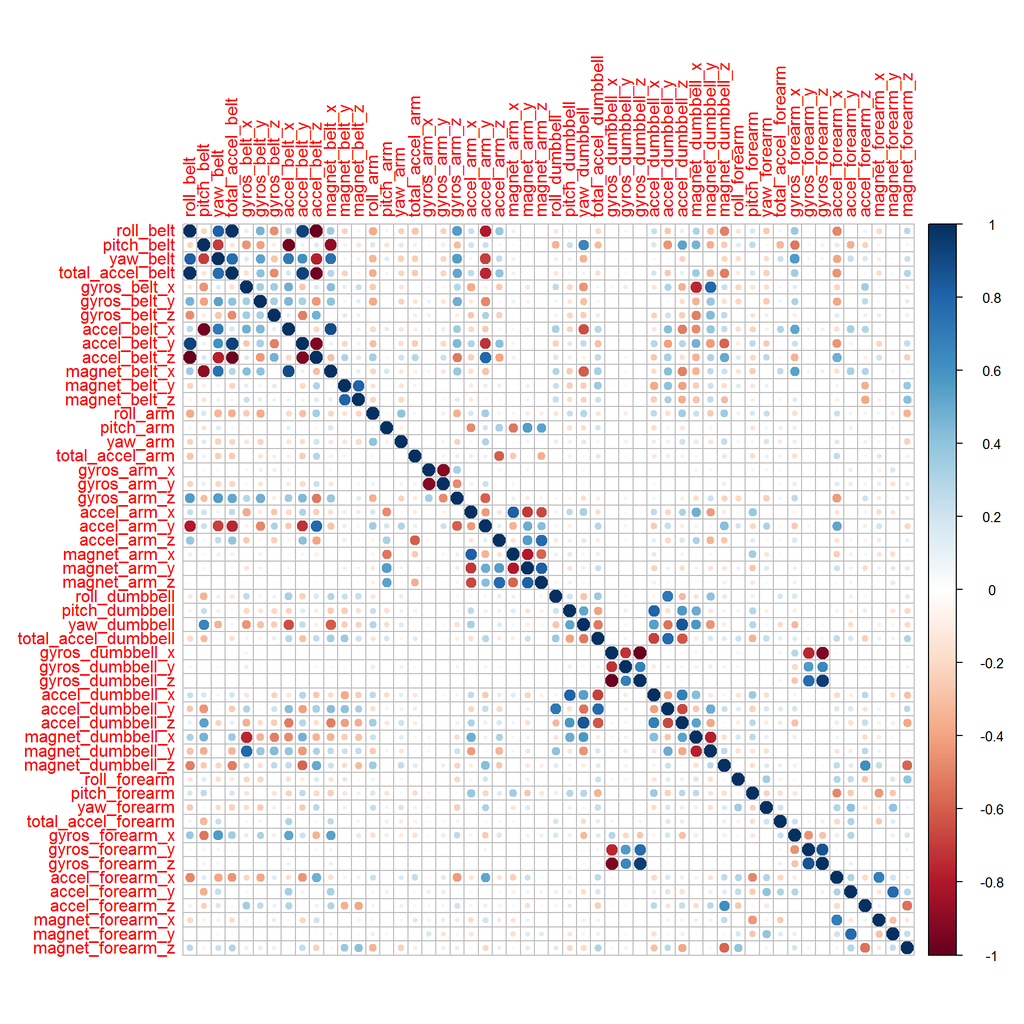

```r
corrplot(cm, method = "circle")
```

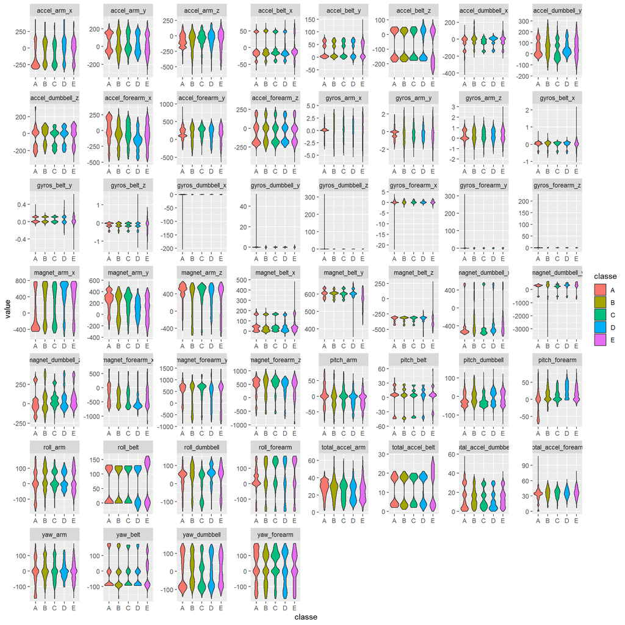

```r
ggplot(tidy_training, aes(x = classe, y = value, fill = classe)) +
  geom_violin() +
  facet_wrap(~name, scale = "free")
```

```r
# Build model
# mod <- train(classe~ ., data = training, method = "gbm")
load("mod.RData")

pred <- predict(mod, testing)

confusionMatrix(pred, as.factor(testing$classe))$overall['Accuracy']
```

```
##  Accuracy
## 0.9763458
```

Following are the predictions based on the 20 test data-points.

```r
# Final Prediction
final_pred <- read_csv("data/pml-testing.csv", col_types = col_classes)
final_pred <- final_pred[, col_ids]
final_pred <- final_pred[, -(1:7)]

predict(mod, final_pred)
```

```
##  [1] B A B A A E D B A A B C B A E E A B B B
## Levels: A B C D E
```